# Project Python Foundations: FoodHub Data Analysis

**Marks: 60**

### Context

The number of restaurants in New York is increasing day by day. Lots of students and busy professionals rely on those restaurants due to their hectic lifestyles. Online food delivery service is a great option for them. It provides them with good food from their favorite restaurants. A food aggregator company FoodHub offers access to multiple restaurants through a single smartphone app.

The app allows the restaurants to receive a direct online order from a customer. The app assigns a delivery person from the company to pick up the order after it is confirmed by the restaurant. The delivery person then uses the map to reach the restaurant and waits for the food package. Once the food package is handed over to the delivery person, he/she confirms the pick-up in the app and travels to the customer's location to deliver the food. The delivery person confirms the drop-off in the app after delivering the food package to the customer. The customer can rate the order in the app. The food aggregator earns money by collecting a fixed margin of the delivery order from the restaurants.

### Objective

The food aggregator company has stored the data of the different orders made by the registered customers in their online portal. They want to analyze the data to get a fair idea about the demand of different restaurants which will help them in enhancing their customer experience. Suppose you are hired as a Data Scientist in this company and the Data Science team has shared some of the key questions that need to be answered. Perform the data analysis to find answers to these questions that will help the company to improve the business.

### Data Description

The data contains the different data related to a food order. The detailed data dictionary is given below.

### Data Dictionary

- order_id: Unique ID of the order
- customer_id: ID of the customer who ordered the food
- restaurant_name: Name of the restaurant
- cuisine_type: Cuisine ordered by the customer
- cost: Cost of the order
- day_of_the_week: Indicates whether the order is placed on a weekday or weekend (The weekday is from Monday to Friday and the weekend is Saturday and Sunday)
- rating: Rating given by the customer out of 5
- food_preparation_time: Time (in minutes) taken by the restaurant to prepare the food. This is calculated by taking the difference between the timestamps of the restaurant's order confirmation and the delivery person's pick-up confirmation.
- delivery_time: Time (in minutes) taken by the delivery person to deliver the food package. This is calculated by taking the difference between the timestamps of the delivery person's pick-up confirmation and drop-off information

### Let us start by importing the required libraries

```python
# import libraries for data manipulation
import numpy as np
import pandas as pd

# import libraries for data visualization
import matplotlib.pyplot as plt
import seaborn as sns

%matplotlib inline
pd.set_option('display.float_format',lambda x: '%.2f'%x)
```

### Understanding the structure of the data

```python
# uncomment and run the following lines for Google Colab
#from google.colab import drive
#drive.mount('/content/drive')
```

```python
# read the data
df = pd.read_csv('C:\\Users\\DELL\\Downloads\\foodhub_order.csv')
# returns the first 5 rows
df.head()
```

|  | order_id | customer_id | restaurant_name | cuisine_type | cost_of_the_order | day_of_the_week | rating | food_preparation_time | delivery_time |
| --- | --- | --- | --- | --- | --- | --- | --- | --- | --- |
| 0 | 1477147 | 337525 | Hangawi | Korean | 30.75 | Weekend | Not given | 25 | 20 |
| 1 | 1477685 | 358141 | Blue Ribbon Sushi Izakaya | Japanese | 12.08 | Weekend | Not given | 25 | 23 |
| 2 | 1477070 | 66393 | Cafe Habana | Mexican | 12.23 | Weekday | 5 | 23 | 28 |
| 3 | 1477334 | 106968 | Blue Ribbon Fried Chicken | American | 29.20 | Weekend | 3 | 25 | 15 |
| 4 | 1478249 | 76942 | Dirty Bird to Go | American | 11.59 | Weekday | 4 | 25 | 24 |

#### Observations:

The DataFrame has 9 columns as mentioned in the Data Dictionary. Data in each row corresponds to the order placed by a customer.

### **Question 1:** How many rows and columns are present in the data? [0.5 mark]

```python
# Write your code here
df.shape
```

```
(1898, 9)
```

#### Observations:

There are **1898 Rows** and **9 Columns** in the given data

### **Question 2:** What are the datatypes of the different columns in the dataset? (The info() function can be used) [0.5 mark]

```python
# Use info() to print a concise summary of the DataFrame
df.info()
```

```
<class 'pandas.core.frame.DataFrame'>
RangeIndex: 1898 entries, 0 to 1897
Data columns (total 9 columns):
 #   Column                 Non-Null Count  Dtype
---  ------                 --------------  -----
 0   order_id               1898 non-null   int64
 1   customer_id            1898 non-null   int64
 2   restaurant_name        1898 non-null   object
 3   cuisine_type           1898 non-null   object
 4   cost_of_the_order      1898 non-null   float64
 5   day_of_the_week        1898 non-null   object
 6   rating                 1898 non-null   object
 7   food_preparation_time  1898 non-null   int64
 8   delivery_time          1898 non-null   int64
dtypes: float64(1), int64(4), object(4)
memory usage: 133.6+ KB
```

#### Observations:

- There are **5 numerical** (4 int & 1 float) and **4 object** datatypes.
- But the rating column data has been categorised as object type.

### **Question 3:** Are there any missing values in the data? If yes, treat them using an appropriate method. [1 mark]

```python
# Write your code here
df.isnull().sum()
```

```
order_id                 0
customer_id              0
restaurant_name          0
cuisine_type             0
cost_of_the_order        0
day_of_the_week          0
rating                   0
food_preparation_time    0
delivery_time            0
dtype: int64
```

#### Observations:

There are **no missing** values in the data.

### **Question 4:** Check the statistical summary of the data. What is the minimum, average, and maximum time it takes for food to be prepared once an order is placed? [2 marks]

```python
# Write your code here
df.describe().T
```

|  | count | mean | std | min | 25% | 50% | 75% | max |
| --- | --- | --- | --- | --- | --- | --- | --- | --- |
| order_id | 1898.00 | 1477495.50 | 548.05 | 1476547.00 | 1477021.25 | 1477495.50 | 1477969.75 | 1478444.00 |
| customer_id | 1898.00 | 171168.48 | 113698.14 | 1311.00 | 77787.75 | 128600.00 | 270525.00 | 405334.00 |
| cost_of_the_order | 1898.00 | 16.50 | 7.48 | 4.47 | 12.08 | 14.14 | 22.30 | 35.41 |
| food_preparation_time | 1898.00 | 27.37 | 4.63 | 20.00 | 23.00 | 27.00 | 31.00 | 35.00 |
| delivery_time | 1898.00 | 24.16 | 4.97 | 15.00 | 20.00 | 25.00 | 28.00 | 33.00 |

#### Observations:

The **minimum, average,** and **maximum** time it takes for food to be prepared once an order is placed is **20 mins , 27 mins** and **35 mins** respectively.

### **Question 5:** How many orders are not rated? [1 mark]

```python
# Write the code here
df['rating'].value_counts()
```

```
Not given    736
5            588
4            386
3            188
Name: rating, dtype: int64
```

#### Observations:

There are **736 unrated** orders which accounts to **39%** of the rating column data.

### Exploratory Data Analysis (EDA)

### **Question 6:** Explore all the variables and provide observations on their distributions. (Generally, histograms, boxplots, countplots, etc. are used for univariate exploration.) [9 marks]

## Type of cuisines

```python
df['cuisine_type'].nunique()
```

```
14
```

```python
df['cuisine_type'].unique()
```

```
array(['Korean', 'Japanese', 'Mexican', 'American', 'Indian', 'Italian',
       'Mediterranean', 'Chinese', 'Middle Eastern', 'Thai', 'Southern',
       'French', 'Spanish', 'Vietnamese'], dtype=object)
```

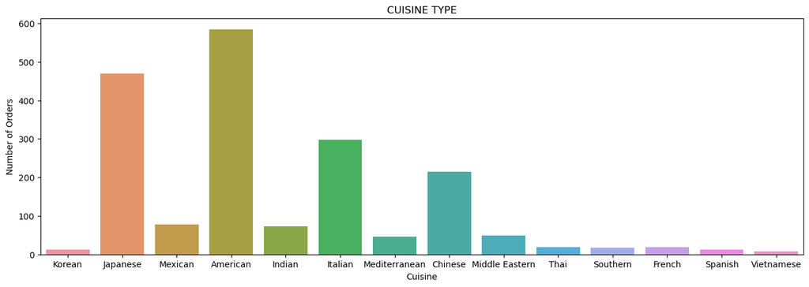

```python
# Write the code here
plt.figure(figsize =(16,5))
sns.countplot(data=df,x='cuisine_type');
plt.title("CUISINE TYPE");
plt.xlabel('Cuisine');
plt.ylabel('Number of Orders');
```

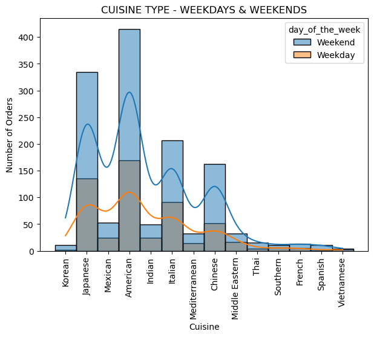

```python
plt.figure(figsize=(7,5))
sns.histplot(data = df, x = 'cuisine_type', hue = 'day_of_the_week', kde = True)
plt.xticks(rotation=90);
plt.title("CUISINE TYPE - WEEKDAYS & WEEKENDS");
plt.xlabel('Cuisine');
plt.ylabel('Number of Orders');
```

Observations:

- There are a total **14** type of cuisines.
- The most popular among the cuisine type is **American** followed by **Japanese, Italian** & **Chinese** respectively.
- There are considerably more number of orders on the weekends for each cuisine type as compared to weekdays.
- **American Cuisine** is the most ordered both during the weekends and weekdays.

## Order cost

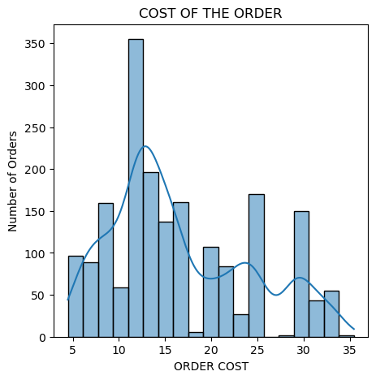

```python
plt.figure(figsize =(5,5))
sns.histplot(data=df,x='cost_of_the_order',kde=True);
plt.title("COST OF THE ORDER");
plt.xlabel('ORDER COST');
plt.ylabel('Number of Orders');
```

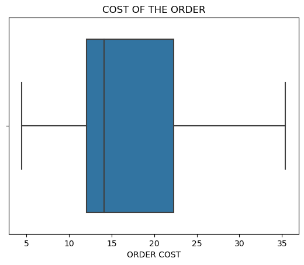

```python
sns.boxplot(data=df,x='cost_of_the_order');
plt.title("COST OF THE ORDER");
plt.xlabel('ORDER COST');
```

### Observations:

- The cost of order shows right skewness
- The maximum number of orders cost are in the range of 11 to 14 dollars.
- There are no outliers present

## Day of the week

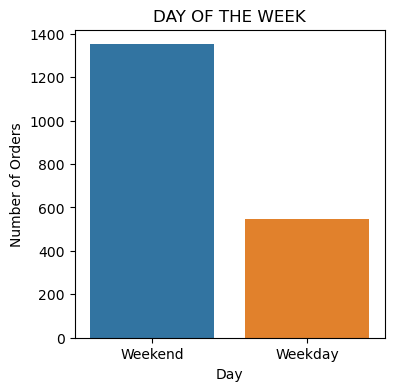

```python
plt.figure(figsize=(4,4))
sns.countplot(data=df,x='day_of_the_week');
plt.title("DAY OF THE WEEK");
plt.xlabel('Day');
plt.ylabel('Number of Orders');
```

```python
df['day_of_the_week'].value_counts(normalize=True)
```

```
Weekend   0.71
Weekday   0.29
Name: day_of_the_week, dtype: float64
```

#### Observations:

Majority of orders are placed on the weekend

- weekend orders - 71%
- weekday orders - 29%

## Ratings

```python
df['rating'].value_counts()
```

```
Not given    736
5            588
4            386
3            188
Name: rating, dtype: int64
```

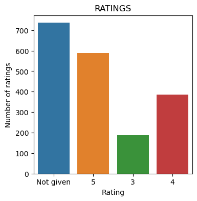

```python
plt.figure(figsize=(4,4))
sns.countplot(data=df,x='rating');
plt.title("RATINGS");
plt.xlabel('Rating');
plt.ylabel('Number of ratings');
```

#### Observations:

- A large number of orders are unrated.
- The rated orders got an above average rating.
- Ratings were distributed as follows:

  ```
    1.   736 orders unrated
    2.   588 orders were rated 5
    3.   386 orders were rated 4
    4.   188 orders were rated 3
  ```

## Food preperation time

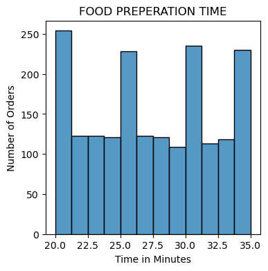

```python
plt.figure(figsize =(4,4))
sns.histplot(data=df,x='food_preparation_time');
plt.title("FOOD PREPERATION TIME");
plt.xlabel('Time in Minutes');
plt.ylabel('Number of Orders');
```

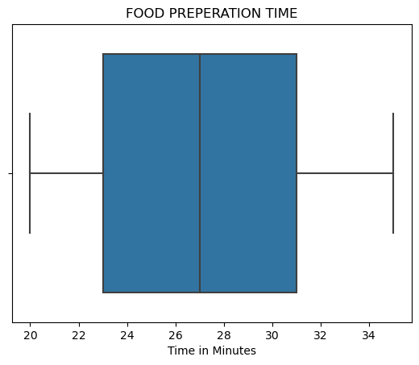

```python
sns.boxplot(data=df,x='food_preparation_time');
plt.title("FOOD PREPERATION TIME");
plt.xlabel('Time in Minutes');
```

#### Observations:

- Time taken for the food preperation
  - Minimum is 20 mins
  - Median is 27 mins which is same as the Mean
  - Maximum is 35 mins

## Delivery Time

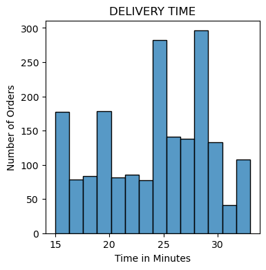

```python
plt.figure(figsize =(4,4))
sns.histplot(data=df,x='delivery_time');
plt.title("DELIVERY TIME");
plt.xlabel('Time in Minutes');
plt.ylabel('Number of Orders');
```

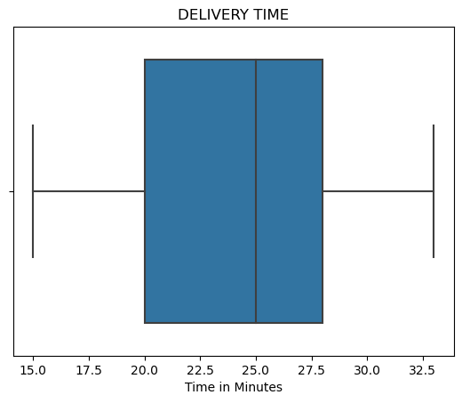

```python
sns.boxplot(data=df,x='delivery_time');
plt.title("DELIVERY TIME");
plt.xlabel('Time in Minutes');
```

#### Observations:

- Time taken for Delivery:
  - Minimum is 15 mins
  - Median is 25 mins
  - Maximum is 33 mins aproximately

### **Question 7**: Which are the top 5 restaurants in terms of the number of orders received? [1 mark]

```python
# Write the code here
df['restaurant_name'].value_counts().head(5)
```

```
Shake Shack                  219
The Meatball Shop            132
Blue Ribbon Sushi            119
Blue Ribbon Fried Chicken     96
Parm                          68
Name: restaurant_name, dtype: int64
```

```python
df['restaurant_name'].nunique()
```

```
178
```

#### Observations:

The top 5 restaurants in terms of number of orders recieved are:

1. Shake Shack (219 orders)
2. The Meatball Shop (132 orders)
3. Blue Ribbon Sushi (119 orders)
4. Blue Ribbon Fried Chicken (96 orders)
5. Parm (68 orders)

There are a total of 178 restaurants provided by the app.

### **Question 8**: Which is the most popular cuisine on weekends? [1 mark]

```python
# Write the code here
df.loc[(df['day_of_the_week'] == 'Weekend'),'cuisine_type'].value_counts().head(1)
```

```
American    415
Name: cuisine_type, dtype: int64
```

#### Observations:

The **American Cuisine** is the most popular cuisine on weekends.

### **Question 9**: What percentage of the orders cost more than 20 dollars? [2 marks]

```python
# Write the code here
more_than_20=df[df['cost_of_the_order']>20].shape[0]
percentage_more_than_20=round((more_than_20/df.shape[0]*100),2)
percentage_more_than_20
```

```
29.24
```

#### Observations:

Approximately **29.24 %** of orders cost more than 20 dollars.

### **Question 10**: What is the mean order delivery time? [1 mark]

```python
# Write the code here
round(df['delivery_time'].mean())
```

```
24
```

#### Observations:

The Mean order delivery time is around **24** minutes.

### **Question 11:** The company has decided to give 20% discount vouchers to the top 3 most frequent customers. Find the IDs of these customers and the number of orders they placed. [1 mark]

```python
# Write the code here
df['customer_id'].value_counts().head(3)
```

```
52832    13
47440    10
83287     9
Name: customer_id, dtype: int64
```

```python
df['customer_id'].nunique()
```

```
1200
```

#### Observations:

Top 3 customer id's with frequent orders are:

1. 52832 with 13 orders
2. 47440 with 10 orders
3. 83287 with 9 orders

There are a total of 1200 customers.

### **Question 12**: Perform a multivariate analysis to explore relationships between the important variables in the dataset. (It is a good idea to explore relations between numerical variables as well as relations between numerical and categorical variables) [10 marks]

```python
df.loc[:,['cost_of_the_order','food_preparation_time','delivery_time']].corr()
```

|  | cost_of_the_order | food_preparation_time | delivery_time |
| --- | --- | --- | --- |
| cost_of_the_order | 1.00 | 0.04 | -0.03 |
| food_preparation_time | 0.04 | 1.00 | 0.01 |
| delivery_time | -0.03 | 0.01 | 1.00 |

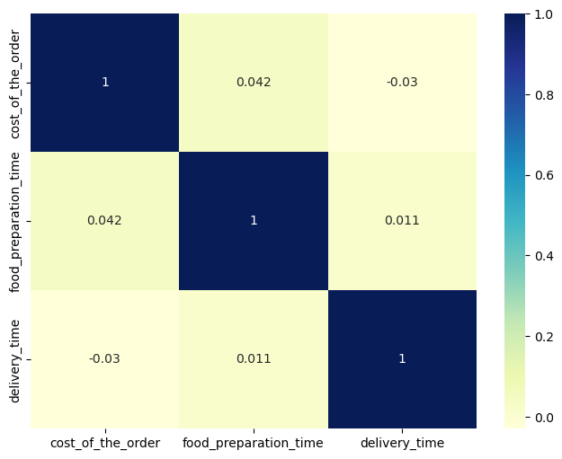

```python
plt.figure(figsize =(8,6))
sns.heatmap(data=df[['cost_of_the_order','food_preparation_time','delivery_time']].corr(), annot=True, cmap='YlGnBu');
```

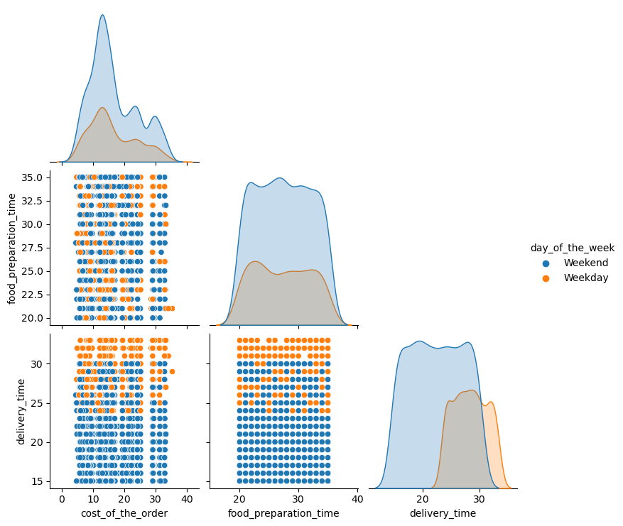

```python
sns.pairplot(data=df, vars=['cost_of_the_order','food_preparation_time','delivery_time'], hue='day_of_the_week',corner=True);
```

### Observations:

There is a little to no corelation between numerical variables.

### Customers & Order Count

```python
df_count=df.groupby(['customer_id'])['order_id'].agg(['count']).sort_values('count',ascending=True).reset_index()
df_customers=df_count.groupby(['count'])['customer_id'].nunique().reset_index().rename(columns={'count':'Count','customer_id':'Customers'})
df_customers.index = np.arange(1, len(df_customers) + 1)
df_customers
```

|  | Count | Customers |
| --- | --- | --- |
| 1 | 1 | 784 |
| 2 | 2 | 267 |
| 3 | 3 | 83 |
| 4 | 4 | 33 |
| 5 | 5 | 19 |
| 6 | 6 | 6 |
| 7 | 7 | 4 |
| 8 | 8 | 1 |
| 9 | 9 | 1 |
| 10 | 10 | 1 |
| 11 | 13 | 1 |

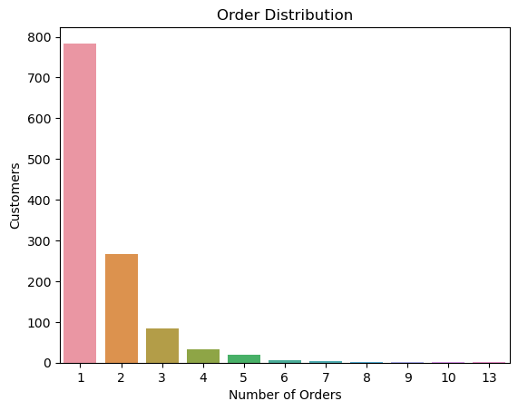

```python
sns.barplot(df_customers,x='Count',y='Customers');
plt.title("Order Distribution");
plt.xlabel('Number of Orders');
plt.ylabel('Customers');
```

#### Observations:

The number of customers who ordered once is significantly high.

## Cuisine Type & Order cost

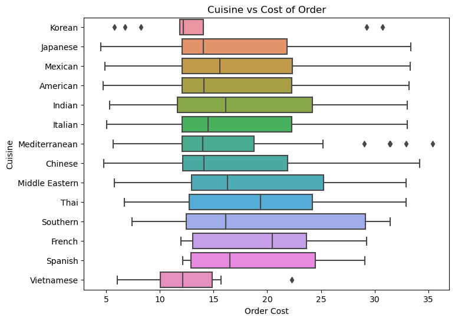

```python
# Write the code here
plt.figure(figsize=(8,6))
sns.boxplot(data = df,y = "cuisine_type", x = "cost_of_the_order");
plt.title("Cuisine vs Cost of Order");
plt.ylabel('Cuisine');
plt.xlabel('Order Cost');
```

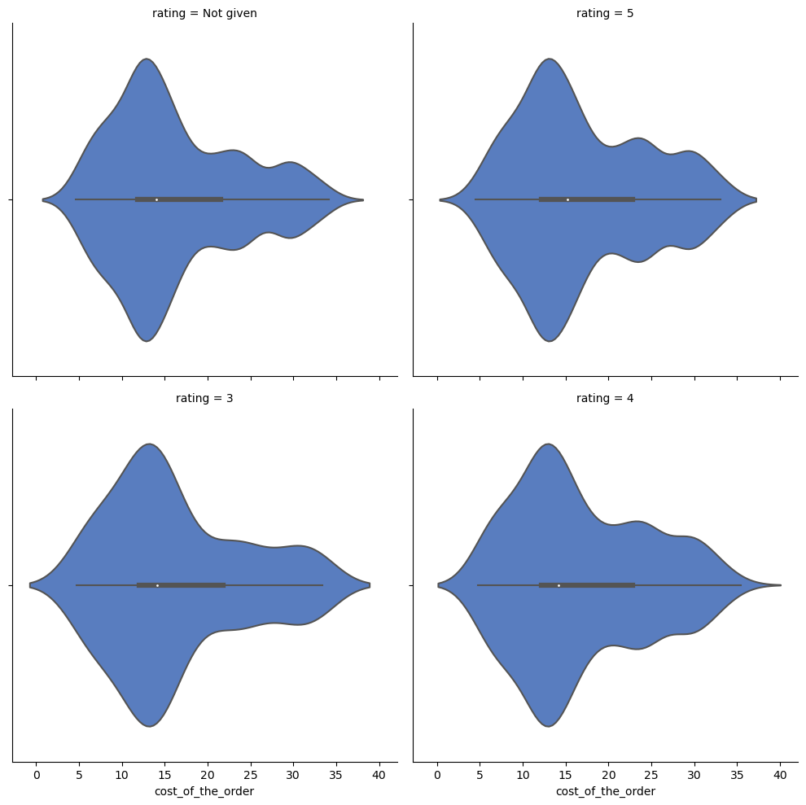

```python
plt.figure(figsize=(5,4));
sns.catplot(data=df, x="cost_of_the_order", col="rating", kind='violin',col_wrap=2, palette='muted');
```

#### Observations:

- The median of the cost of order for all the types of cuisine is below 20 dollars except for the french cuisine.
- The ratings are almost identical regardless to the cost of the order.
- There are few outlers for Korean , Mediteranean & Vietnamese Cuisine.

## Cuisine & Food preperation time

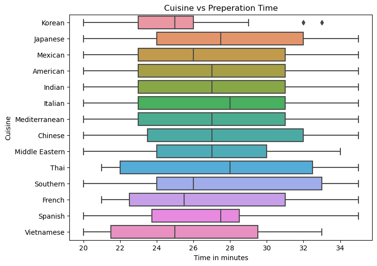

```python
plt.figure(figsize=(8,6))
sns.boxplot(data = df,y = "cuisine_type", x = "food_preparation_time");
plt.title("Cuisine vs Preperation Time");
plt.xlabel('Time in minutes');
plt.ylabel('Cuisine');
```

#### Observations:

- The median of the food preperation time for all the types of cuisine is equal to or below 28 minutes.
- There are some outliers for Korean cuisine.

## Order Cost & Delivery Time

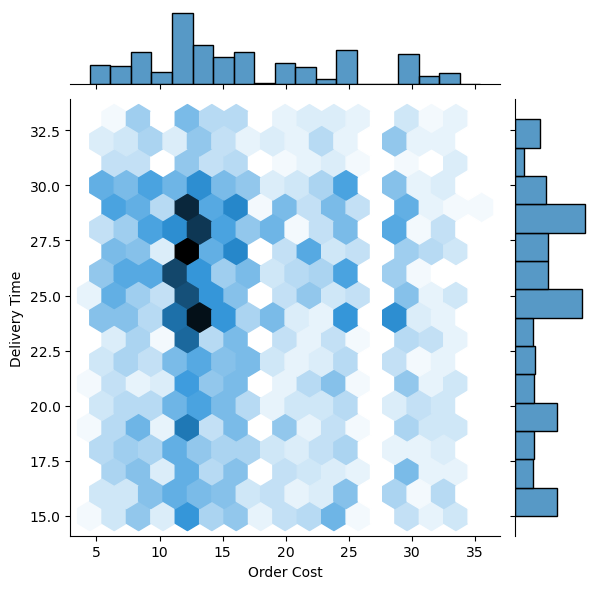

```python
sns.jointplot(data = df, x ='cost_of_the_order', y = 'delivery_time',kind='hex');
plt.xlabel('Order Cost');
plt.ylabel('Delivery Time');
```

#### Observations:

The cost orders are dense in the range of 10 to 15 dollars and a delivery time of 23 to 29 minutes

## Day of the Week & Delivery Time

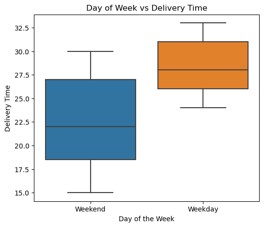

```python
plt.figure(figsize=(6,5))
sns.boxplot(data = df,x = "day_of_the_week", y = "delivery_time");
plt.title("Day of Week vs Delivery Time");
plt.xlabel('Day of the Week');
plt.ylabel('Delivery Time');
```

#### Observations:

- Delivery time is slightly higher during the weekdays compared to the weekends.
- The delivery time on the weekdays is approximately 24 minutes minimum to a maximum of 33 minutes with an average of 28 mins.
- The delivery time in weekends ranges from a minimum of 15 minutes to a maximum of 30 minutes with an average of 22 minutes.

### **Question 13:** The company wants to provide a promotional offer in the advertisement of the restaurants. The condition to get the offer is that the restaurants must have a rating count of more than 50 and the average rating should be greater than 4. Find the restaurants fulfilling the criteria to get the promotional offer. [3 marks]

```python
# Write the code here
rated=df.loc[df['rating']!='Not given'].copy()
rated['rating']=rated['rating'].astype('int')
df_rating_count=rated.groupby(['restaurant_name'])['rating'].agg(['count','mean']).sort_values(by='count',ascending=False)
rest_names=df_rating_count[df_rating_count['count']>50].reset_index()
rest_names.index = np.arange(1, len(rest_names) + 1)
rest_names
```

|  | restaurant_name | count | mean |
| --- | --- | --- | --- |
| 1 | Shake Shack | 133 | 4.28 |
| 2 | The Meatball Shop | 84 | 4.51 |
| 3 | Blue Ribbon Sushi | 73 | 4.22 |
| 4 | Blue Ribbon Fried Chicken | 64 | 4.33 |

#### Observations:

Top restaurants based on count and mean are:

1. Shake Shack
2. The Meatball Shop
3. Blue Ribbon Sushi
4. Blue Ribbon Fried Chicken

### **Question 14:** The company charges the restaurant 25% on the orders having cost greater than 20 dollars and 15% on the orders having cost greater than 5 dollars. Find the net revenue generated by the company across all orders. [3 marks]

```python
# Write the code here
def revenue(x):
    if x > 20:
        return x*0.25
    elif x > 5:
        return x*0.15
    else:
        return x*0
df['Revenue'] = df['cost_of_the_order'].apply(revenue)
net_revenue=round(df['Revenue'].sum(),2)
net_revenue
```

```
6166.3
```

#### Observations:

- The total net revenue generated is 6166.30 dollars.

### **Question 15:** The company wants to analyze the total time required to deliver the food. What percentage of orders take more than 60 minutes to get delivered from the time the order is placed? (The food has to be prepared and then delivered.) [2 marks]

```python
# Write the code here
df['total_time']=df['food_preparation_time'] + df['delivery_time']
time_above_60=df['total_time'][df['total_time']>60].count()
total=df['total_time'].count()
percentage_60=round((time_above_60/total)*100,2)
percentage_60
```

```
10.54
```

#### Observations:

Around **10.54 %** of orders take more than 60 minutes to get delivered from the time the order is placed

### **Question 16:** The company wants to analyze the delivery time of the orders on weekdays and weekends. How does the mean delivery time vary during weekdays and weekends? [2 marks]

```python
# Write the code here
weekday=df[df['day_of_the_week'] == 'Weekday']['delivery_time'].mean()
print("weekday :",round(weekday),'mins')
weekend=df[df['day_of_the_week'] == 'Weekend']['delivery_time'].mean()
print("weekend :",round(weekend),'mins')
```

```
weekday : 28 mins
weekend : 22 mins
```

### Conclusion and Recommendations

### **Question 17:** What are your conclusions from the analysis? What recommendations would you like to share to help improve the business? (You can use cuisine type and feedback ratings to drive your business recommendations.) [6 marks]

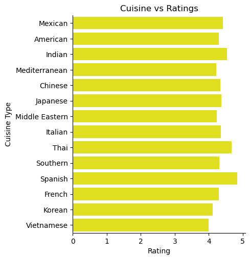

```python
sns.catplot(data=rated,y='cuisine_type',x='rating',kind='bar',color='yellow',errorbar=None);
plt.title("Cuisine vs Ratings");
plt.xlabel('Rating');
plt.ylabel('Cuisine Type');
```

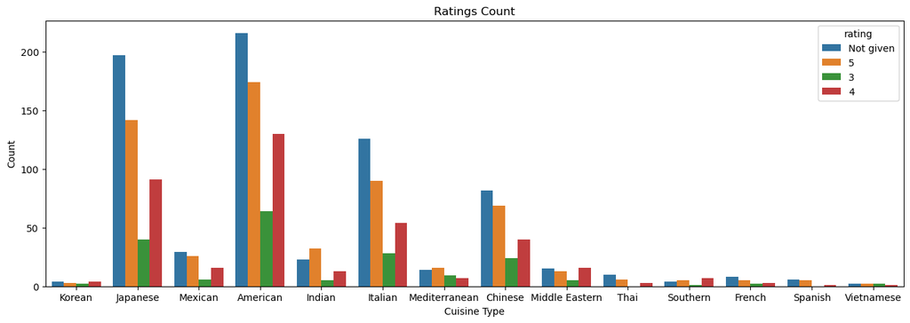

```python
plt.figure(figsize=(16,5));
sns.countplot(data=df,x='cuisine_type',hue= 'rating');
plt.title("Ratings Count");
plt.xlabel('Cuisine Type');
plt.ylabel('Count');
```

```python
df.groupby(['restaurant_name'])['order_id'].agg(['count']).sort_values('count',ascending=False).head(10)
```

| restaurant_name | count |
| --- | --- |
| Shake Shack | 219 |
| The Meatball Shop | 132 |
| Blue Ribbon Sushi | 119 |
| Blue Ribbon Fried Chicken | 96 |
| Parm | 68 |
| RedFarm Broadway | 59 |
| RedFarm Hudson | 55 |
| TAO | 49 |
| Han Dynasty | 46 |
| Blue Ribbon Sushi Bar & Grill | 44 |

```python
rated.groupby(['cuisine_type'])['rating'].agg(['count','mean'])
```

| cuisine_type | count | mean |
| --- | --- | --- |
| American | 368 | 4.30 |
| Chinese | 133 | 4.34 |
| French | 10 | 4.30 |
| Indian | 50 | 4.54 |
| Italian | 172 | 4.36 |
| Japanese | 273 | 4.37 |
| Korean | 9 | 4.11 |
| Mediterranean | 32 | 4.22 |
| Mexican | 48 | 4.42 |
| Middle Eastern | 34 | 4.24 |
| Southern | 13 | 4.31 |
| Spanish | 6 | 4.83 |
| Thai | 9 | 4.67 |
| Vietnamese | 5 | 4.00 |

- All the cuisines provided by the app which are rated have a high average ratings.
- Each cuisine have a lot of unrated orders,this suggests that most of the customers are not interested to rate the orders.
- Shake shack has the most number of orders followed by The meat ball shop.

### Recommendations:

- Promotional offers for the Spanish,Thai,Indian and French cuisines as they have good ratings but less number of orders.
- Delivery Time on weekends is less with more number of orders as compared to weekdays so number of delivery agents can be reduced on weekends.
- Incentives like app cashback on the first order for new customers as most of the customers have ordered only once.
- Majority of orders are unrated:

  ```
   1.   An option to provide ratings on the previous order if not rated before.
   2.   Provide notification reminder for the customer to rate the order after some time interval.
   3.   Delivery agents can remind the customer to rate the order on delivery.
  ```

- As the weekdays provide less business compared to weekends,more effort should be made in marketing for the weekdays.For example the app can provide phone notifications ahead of lunch hours for working proffesionals.
- A survey can be carried out to understand the most important factor a customer considers before ordering the food.(Example- Restaurant-name,price,rating,ease of order etc)